# EDA - Don River Streamflow

Dylan

2026-03-20

## 1. Load Data

```r
library(tidyverse)
library(lubridate)
library(here)

flow_data <- read_csv(here::here("data", "clean", "02HC024_clean.csv"))
```

## 2. Data Quality Checks

### Structure

```r
glimpse(flow_data)
```

```
## Rows: 22,372
## Columns: 9
## $ date            <date> 1962-10-01, 1962-10-02, 1962-10-03, 1962-10-04, 1962-…
## $ flow            <dbl> 2.15, 1.98, 1.87, 1.87, 6.37, 4.25, 2.71, 2.15, 2.04, …
## $ symbol_flag     <chr> NA, NA, NA, NA, NA, NA, NA, NA, NA, NA, NA, NA, NA, NA…
## $ year            <dbl> 1962, 1962, 1962, 1962, 1962, 1962, 1962, 1962, 1962, …
## $ month           <dbl> 10, 10, 10, 10, 10, 10, 10, 10, 10, 10, 10, 10, 10, 10…
## $ day             <dbl> 1, 2, 3, 4, 5, 6, 7, 8, 9, 10, 11, 12, 13, 14, 15, 16,…
## $ hydrologic_year <dbl> 1963, 1963, 1963, 1963, 1963, 1963, 1963, 1963, 1963, …
## $ season          <chr> "Fall", "Fall", "Fall", "Fall", "Fall", "Fall", "Fall"…
## $ quality         <chr> "measured", "measured", "measured", "measured", "measu…
```

```r
head(flow_data)
```

```
## # A tibble: 6 × 9
##   date        flow symbol_flag  year month   day hydrologic_year season quality
##   <date>     <dbl> <chr>       <dbl> <dbl> <dbl>           <dbl> <chr>  <chr>
## 1 1962-10-01  2.15 <NA>         1962    10     1            1963 Fall   measured
## 2 1962-10-02  1.98 <NA>         1962    10     2            1963 Fall   measured
## 3 1962-10-03  1.87 <NA>         1962    10     3            1963 Fall   measured
## 4 1962-10-04  1.87 <NA>         1962    10     4            1963 Fall   measured
## 5 1962-10-05  6.37 <NA>         1962    10     5            1963 Fall   measured
## 6 1962-10-06  4.25 <NA>         1962    10     6            1963 Fall   measured
```

### Missing Values & Data Quality

```r
# NA check across all columns
flow_data %>%
  summarise(across(everything(), ~ sum(is.na(.))))
```

```
## # A tibble: 1 × 9
##    date  flow symbol_flag  year month   day hydrologic_year season quality
##   <int> <int>       <int> <int> <int> <int>           <int>  <int>   <int>
## 1     0     0       21562     0     0     0               0      0       0
```

```r
# proportion of each quality flag
quality_summary <- flow_data %>%
  count(quality) %>%
  mutate(proportion = round(n / sum(n) * 100, 1))

quality_summary
```

```
## # A tibble: 4 × 3
##   quality            n proportion
##   <chr>          <int>      <dbl>
## 1 estimated        359        1.6
## 2 ice_conditions   389        1.7
## 3 measured       21562       96.4
## 4 partial_day       62        0.3
```

```r
measured  <- mean(flow_data$quality == "measured")
estimated <- mean(flow_data$quality == "estimated")
ice  <- mean(flow_data$quality == "ice_conditions")
partial <- mean(flow_data$quality == "partial_day")
```

The data is mostly clean: 96.4% of observations are measured values with no quality concern. The remaining 3.6% breaks down as follows: 1.6% estimated (gap-filled), 1.7% ice-affected, and 0.3% partial day recordings.

Ice-affected measurements are worth noting for a flood frequency model as winter flow readings under ice conditions can be unreliable. However at 1.7% of total observations this is not affecting the analysis. All flagged observations are kept but their quality status is carried through as a variable for sensitivity checks if needed.

### Complete Years

```r
incomplete_years <- flow_data %>%
  group_by(year) %>%
  summarise(n_days = n()) %>%
  filter(n_days < 330)

incomplete_years
```

```
## # A tibble: 1 × 2
##    year n_days
##   <dbl>  <int>
## 1  1962     92
```

1 year(s) have fewer than 330 observations: 1962 . These are flagged for potential removal before modeling. The 330 day cutoff represents 90% of the year. The years below this threshold risk underrepresenting flood frequency due to missing observations rather than the absence of events.

### Date Range

```r
range(flow_data$date)
```

```
## [1] "1962-10-01" "2023-12-31"
```

### Negative Or Zero Flows (physically impossible)

```r
sum(flow_data$flow <= 0, na.rm = TRUE)
```

```
## [1] 0
```

### Extreme Values

```r
flow_data %>%
  arrange(desc(flow)) %>%
  select(date, flow, quality) %>%
  head(10)
```

```
## # A tibble: 10 × 3
##    date        flow quality
##    <date>     <dbl> <chr>
##  1 1984-02-14 108   measured
##  2 1980-03-21  86.7 measured
##  3 1986-09-11  85.6 measured
##  4 2009-02-12  80.3 measured
##  5 2000-05-13  76   partial_day
##  6 1986-08-27  75.4 estimated
##  7 1979-12-25  75.3 measured
##  8 1965-02-10  70.2 measured
##  9 2020-01-12  66.7 estimated
## 10 1985-02-24  66.1 measured
```

### Duplicate Dates

```r
flow_data %>%
  count(date) %>%
  filter(n > 1)
```

```
## # A tibble: 0 × 2
## # ℹ 2 variables: date <date>, n <int>
```

### Summary Statistics

```r
flow_data %>%
  summarise(
    n_years     = n_distinct(year),
    n_obs       = n(),
    mean_flow   = round(mean(flow, na.rm = TRUE), 2),
    median_flow = round(median(flow, na.rm = TRUE), 2),
    sd_flow     = round(sd(flow, na.rm = TRUE), 2),
    max_flow    = round(max(flow, na.rm = TRUE), 2),
    p95_flow    = round(quantile(flow, 0.95, na.rm = TRUE), 2),
    p99_flow    = round(quantile(flow, 0.99, na.rm = TRUE), 2)
  )
```

```
## # A tibble: 1 × 8
##   n_years n_obs mean_flow median_flow sd_flow max_flow p95_flow p99_flow
##     <int> <int>     <dbl>       <dbl>   <dbl>    <dbl>    <dbl>    <dbl>
## 1      62 22372      4.11         2.4    5.06      108     12.7     26.1
```

## 3. Distribution

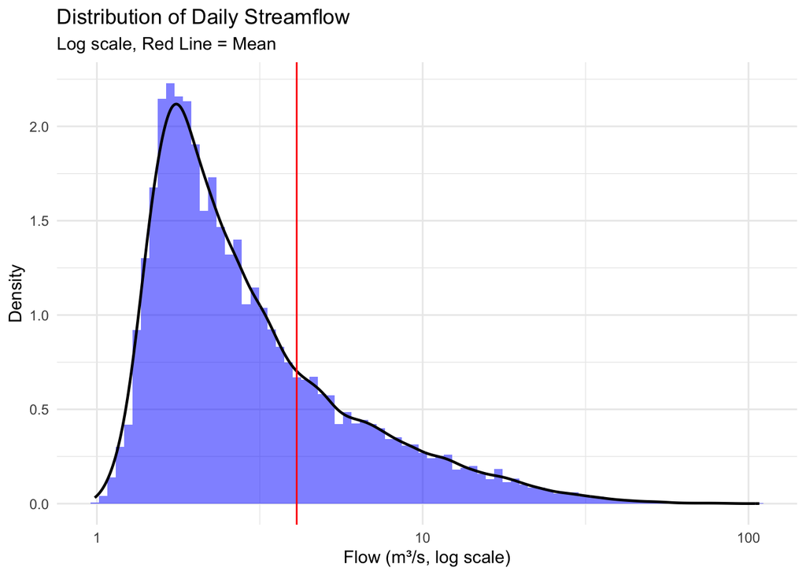

```r
ggplot(flow_data, aes(x = flow)) +
  geom_histogram(aes(y = after_stat(density)),
                 bins = 80, fill = "blue", alpha = .5) +
  geom_density(colour = "black", linewidth = 0.8) +
  geom_vline(xintercept = mean(flow_data$flow), colour = "red") +
  scale_x_log10() +
  theme_minimal() +
  labs(
    title    = "Distribution of Daily Streamflow",
    subtitle = "Log scale, Red Line = Mean",
    x        = "Flow (m³/s, log scale)",
    y        = "Density"
  )
```

## 4a. Seasonality by Month

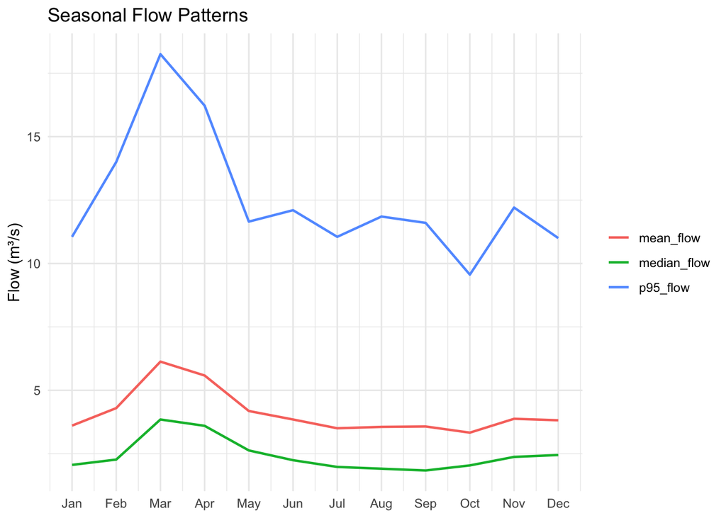

```r
flow_data %>%
  group_by(month) %>%
  summarise(
    mean_flow   = mean(flow, na.rm = TRUE),
    median_flow = median(flow, na.rm = TRUE),
    p95_flow    = quantile(flow, 0.95, na.rm = TRUE)
  ) %>%
  pivot_longer(
    cols      = c(mean_flow, median_flow, p95_flow),
    names_to  = "statistic",
    values_to = "flow"
  ) %>%
  ggplot(aes(x = month, y = flow, colour = statistic)) +
  geom_line(linewidth = 0.8) +
  scale_x_continuous(breaks = 1:12, labels = month.abb) +
  theme_minimal() +
  labs(
    title  = "Seasonal Flow Patterns",
    x      = NULL,
    y      = "Flow (m³/s)",
    colour = NULL
  )
```

## 4b. Seasonal Flow Variation

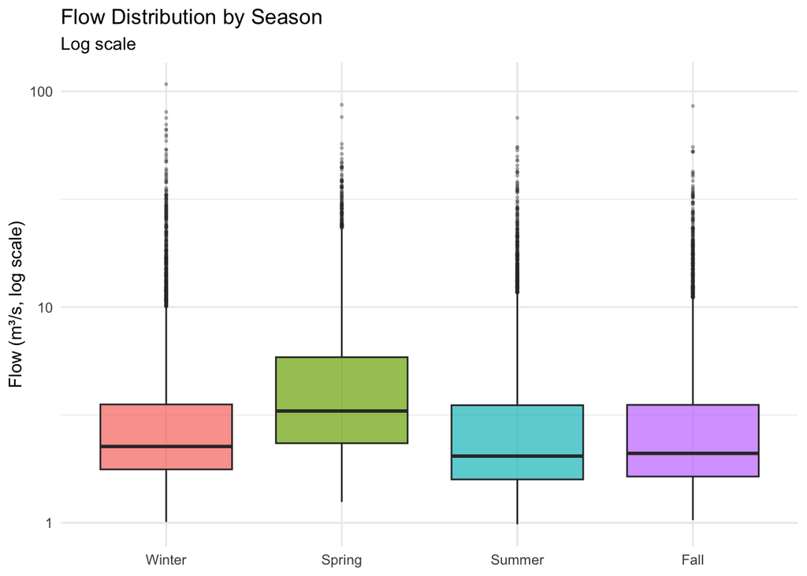

```r
flow_data %>%
  mutate(season = factor(season,
                         levels = c("Winter", "Spring",
                                    "Summer", "Fall"))) %>%
  ggplot(aes(x = season, y = flow, fill = season)) +
  geom_boxplot(alpha = 0.7, outlier.alpha = 0.3, outlier.size = .5) +
  scale_y_log10() +
  theme_minimal() +
  theme(legend.position = "none") +
  labs(
    title    = "Flow Distribution by Season",
    subtitle = "Log scale",
    x        = NULL,
    y        = "Flow (m³/s, log scale)"
  )
```

## 5. Annual Maximum Trend

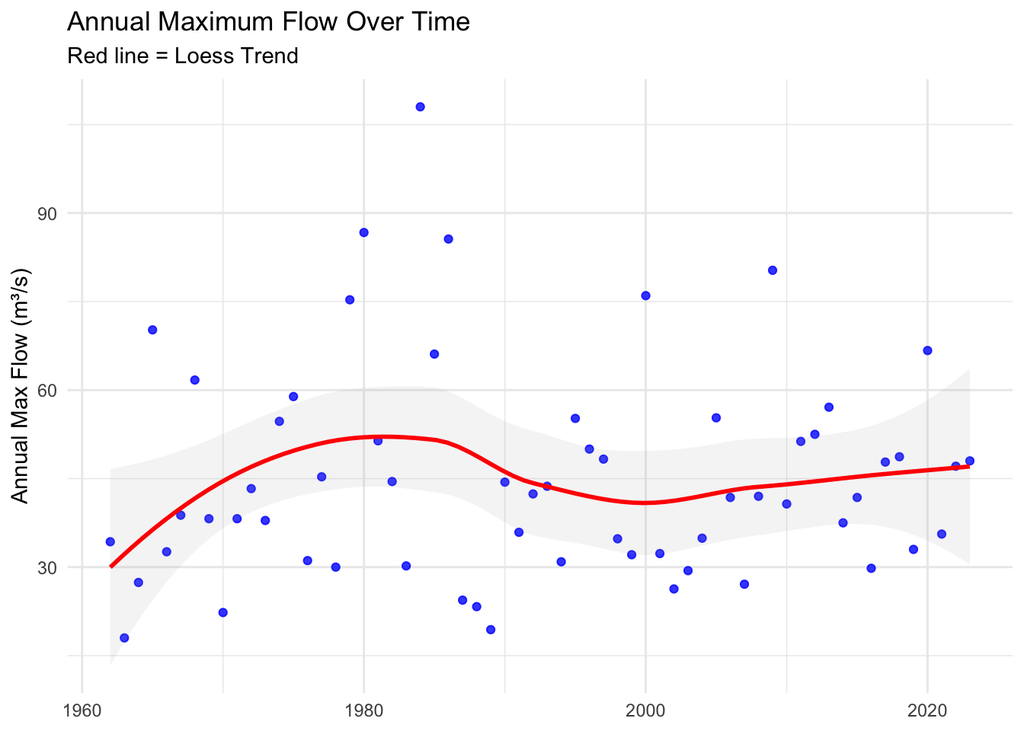

```r
flow_data %>%
  group_by(year) %>%
  summarise(max_flow = max(flow, na.rm = TRUE)) %>%
  ggplot(aes(x = year, y = max_flow)) +
  geom_point(colour = "blue", alpha = 0.8) +
  geom_smooth(method = "loess", colour = "red", se = TRUE, alpha = 0.1) +
  theme_minimal() +
  labs(
    title    = "Annual Maximum Flow Over Time",
    subtitle = "Red line = Loess Trend",
    x        = NULL,
    y        = "Annual Max Flow (m³/s)"
  )
```

## 6. Autocorrelation

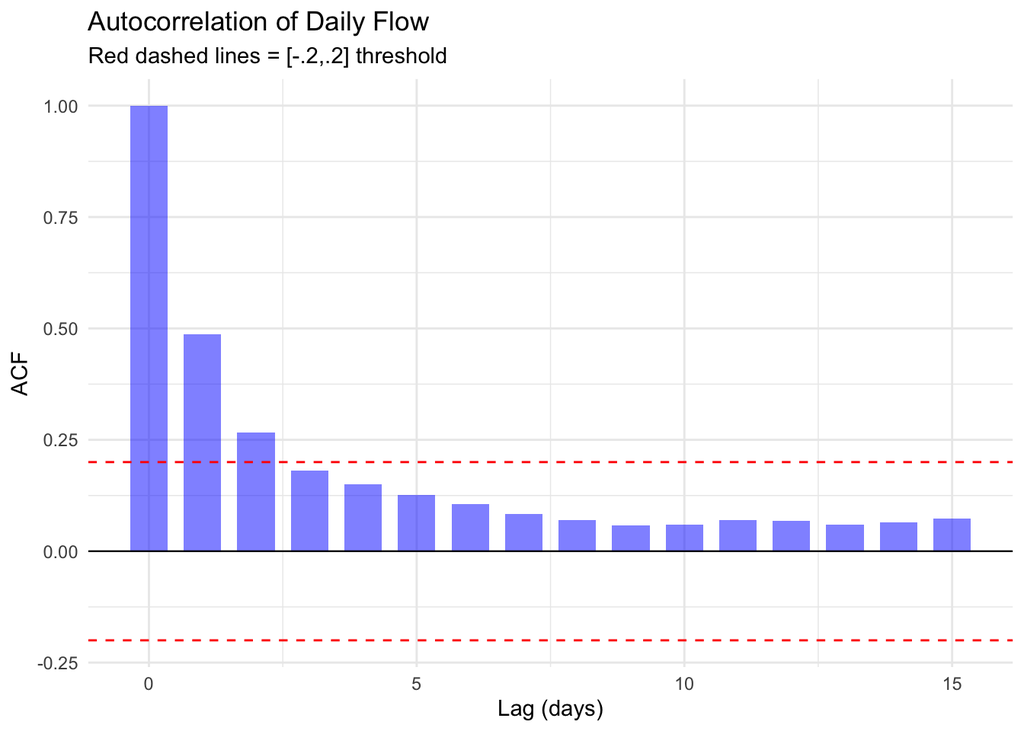

```r
acf_values <- acf(flow_data$flow, lag.max = 15, plot = FALSE)

data.frame(
  lag = as.numeric(acf_values$lag),
  acf = as.numeric(acf_values$acf)
) %>%
  ggplot(aes(x = lag, y = acf)) +
  geom_col(fill = "blue", alpha = 0.5, width = 0.7) +
  geom_hline(yintercept =  0.2, colour = "red",   linetype = "dashed") +
  geom_hline(yintercept = -0.2, colour = "red",   linetype = "dashed") +
  geom_hline(yintercept =  0,   colour = "black", linewidth = 0.4) +
  theme_minimal() +
  labs(
    title    = "Autocorrelation of Daily Flow",
    subtitle = "Red dashed lines = [-.2,.2] threshold",
    x        = "Lag (days)",
    y        = "ACF"
  )
```

High autocorrelation at short lags confirms that consecutive days of elevated flow are not independent, a single storm event produces several correlated days of high flow. This directly motivates the declustering step in the next notebook, where a minimum separation of 3 days between events is used to ensure independence before fitting the Poisson frequency model.

## 7. Key Findings

**Distribution:** Daily streamflow is strongly right skewed with mean > median. The spread between p95, mean, and median widens at higher flow levels meaning the gap between p95 and mean is substantially larger than the gap between mean and median, indicating increasing variance at higher percentiles.

**Seasonality:** Flow peaks between February and mid-April driven by snowmelt. This pattern is consistent across mean, median, and p95. Right skewed behavior persists year-round implying its not driven by a single season.

**Annual maximum trend:** The LOESS smoother reveals a non-monotonic trend. Maxima increased from ~30 m³/s in 1960 to ~50 m³/s by 1980, declined to ~40 m³/s through 2000, and have slowly increased to ~46 m³/s since. No strong linear trend but a modest post-2000 upward signal is visible.

**Autocorrelation:** Strong autocorrelation at short lags as ACF drops below 0.2 at approximately 3 days. Consecutive high flow days are not independent, consistent with multi-day storm drainage behavior.

## 8. Modeling Implications

**GPD for severity:** The right skewed heavy tailed distribution with increasing variance at higher percentiles directly supports GPD as the severity model. Extreme events are not just larger, they are disproportionately more variable. This is characteristic of heavy tailed behavior that GPD is designed to capture. The positive skew also suggests the shape parameter ξ is likely positive, consistent with the prior belief in Gamma(α, β) - 0.3.

**Stationarity assumption:** The non-monotonic LOESS trend and modest post-2000 upward signal suggest some non-stationarity in the historical record. However the absence of a strong monotonic trend means stationarity is a reasonable baseline assumption for Version 1. The observed trend provides empirical motivation for coupling the distributions’ parameters to climate drivers in Version 2.

**Seasonal structure:** The clear February to mid-April peak introduces seasonal variation in flood frequency that a stationary Poisson model ignores. This is a known limitation of Version 1, a seasonal frequency component where λ varies by season is a natural Version 2 extension.